# Homework 1

Author

Mani Jose - 24222863

## Introduction

The *airquality* dataset is built into R and contains daily air quality measurements in New York City from May to September 1973.The goal of collecting this data was to monitor environmental conditions and understand how factors like temperature, wind, and solar radiation impact air pollution, particularly ozone levels, which are harmful to health.

*The airquality dataset contains 153 observations, each representing a single day, it includes 6 variables* :

| Variable | Description |
| --- | --- |
| Ozone | Ozone concentration (ppb) |
| Solar.R | Solar radiation (Langley) |
| Wind | Wind speed (mph) |
| Temp | Maximum daily temperature (°F) |
| Month | Month of the observation |
| Day | Day of the month |

**The objective of this analysis is to explore the airquality dataset by visualizing key weather and pollution variables including:**

1. Use boxplots to compare ozone level across different months, revealing seasonal patterns and variability in air quality and weather.
2. Analyze daily trends in ozone concentration over time through a line plot, providing insight into how air pollution fluctuates across the months.

## Basic summary statistics

```
     Ozone           Solar.R           Wind             Temp
 Min.   :  1.00   Min.   :  7.0   Min.   : 1.700   Min.   :56.00
 1st Qu.: 18.00   1st Qu.:115.8   1st Qu.: 7.400   1st Qu.:72.00
 Median : 31.50   Median :205.0   Median : 9.700   Median :79.00
 Mean   : 42.13   Mean   :185.9   Mean   : 9.958   Mean   :77.88
 3rd Qu.: 63.25   3rd Qu.:258.8   3rd Qu.:11.500   3rd Qu.:85.00
 Max.   :168.00   Max.   :334.0   Max.   :20.700   Max.   :97.00
 NA's   :37       NA's   :7
     Month            Day
 Min.   :5.000   Min.   : 1.0
 1st Qu.:6.000   1st Qu.: 8.0
 Median :7.000   Median :16.0
 Mean   :6.993   Mean   :15.8
 3rd Qu.:8.000   3rd Qu.:23.0
 Max.   :9.000   Max.   :31.0
```

- **Ozone levels** vary widely from a low of 1 ppb to a high of 168 ppb, with a median value of 31.5 ppb and a mean of 42.13 ppb. *The higher mean compared to the median indicates some days with unusually high ozone concentrations* pulling the average upward. However, *37 values are missing*, which could impact analysis accuracy.
- **Solar radiation** (Solar.R) ranges between 7.0 and 334.0 units, with a median of 205.0 and an average of 185.9. *There are 7 missing values*, suggesting some gaps in solar radiation measurement.
- **Wind speeds** *are fairly consistent*, spanning from 1.7 mph to 20.7 mph, with a median of 9.7 mph and a mean of 9.96 mph, *indicating generally moderate wind conditions.*
- **Temperatures** during the recorded period range from 56°F to 97°F, averaging 77.88°F with a median of 79°F, which *aligns with typical late spring and summer weather*.

## Visualizations Of Ozone Levels

This box plot shows how ozone concentration (ppb) varies across the months from May (5) to September (9):

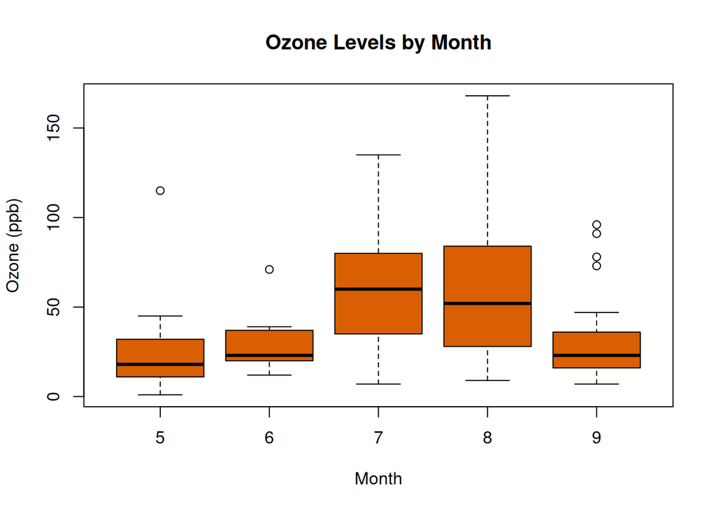

**Ozone levels tend to peak in mid-summer, possibly due to stronger sunlight and higher temperatures which accelerate ozone formation.**

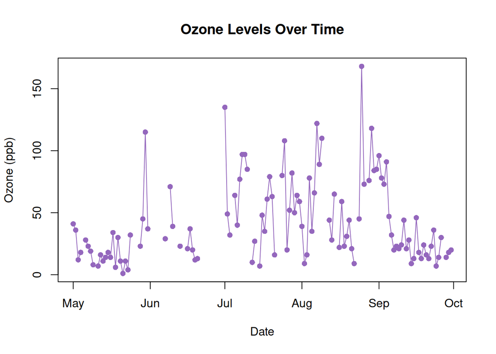

Ozone levels tend to **peak during the warmest months (July–August)**, likely due to increased sunlight and temperature, which are known to enhance ozone formation. The drop-off in September suggests **seasonal effects** strongly influence ozone concentration.